# Burak Nur Erdem IE360 Homework1

## Distribution of household consumption expenditures by types of expenditure

This dataset includes the percantages of expenditure types of housholds in years 2003-2017 by regions. These regions consists of one or few cities and are:

TR10 (İstanbul), TR21 (Tekirdağ, Edirne, Kırklareli), TR22 (Balıkesir, Çanakkale), TR31 (İzmir), TR32 (Aydın, Denizli, Muğla), TR33 (Manisa, Afyon, Kütahya, Uşak), TR41 (Bursa, Eskişehir, Bilecik), TR42 (Kocaeli, Sakarya, Düzce, Bolu, Yalova), TR51 (Ankara), TR52 (Konya, Karaman), TR61 (Antalya, Isparta, Burdur), TR62 (Adana, Mersin), TR63 (Hatay, Kahramanmaraş, Osmaniye), TR71 (Kırıkkale, Aksaray, Niğde, Nevşehir, Kırşehir), TR72 (Kayseri, Sivas, Yozgat), TR81 (Zonguldak, Karabük, Bartın), TR82 (Kastamonu, Çankırı, Sinop), TR83 (Samsun,Tokat, Çorum, Amasya), TR90 (Trabzon, Ordu, Giresun, Rize, Artvin, Gümüşhane), TRA1 (Erzurum, Erzincan, Bayburt), TRA2 (Ağrı, Kars, Iğdır, Ardahan), TRB1 (Malatya, Elazığ, Bingöl, Tunceli), TRB2 (Van, Muş, Bitlis, Hakkari), TRC1 (Gaziantep, Adıyaman, Kilis), TRC2 (Şanlıurfa, Diyarbakır), TRC3 (Mardin, Batman, Şırnak, Siirt),

There are 12 types of expenditures. Below, I inspected 3 of them which are Housing and Rents, Food and Non-alcoholic Beverages, Restaurants and Hotels.

# Measure 1: Housing and Rent

Here are the histograms of housing and rent expenditure percantages of households in different regions by year.

|  | 2003 | 2004 | 2005 | 2006 | 2007 | 2008 | 2009 | 2010 | 2011 | 2012 | 2013 | 2014 | 2015 | 2016 | 2017 |
| --- | --- | --- | --- | --- | --- | --- | --- | --- | --- | --- | --- | --- | --- | --- | --- |
| TR10 | 32.2 | 31.1 | 31.5 | 32.3 | 33.8 | 33.4 | 32.6 | 30.9 | 29.3 | 28.9 | 29.8 | 30.4 | 30.7 | 29.5 | 28.6 |
| TR21 | 26.1 | 23.9 | 25.8 | 27.1 | 27.9 | 27.4 | 25.7 | 23.8 | 23.2 | 24.1 | 25.3 | 25.2 | 24.0 | 22.2 | 21.8 |
| TR22 | 28.6 | 27.0 | 27.1 | 28.5 | 27.5 | 27.1 | 25.6 | 25.9 | 25.2 | 25.8 | 25.1 | 24.9 | 23.6 | 23.0 | 21.5 |
| TR31 | 30.1 | 28.6 | 28.9 | 30.7 | 30.9 | 31.6 | 30.4 | 29.4 | 28.2 | 27.7 | 27.7 | 27.3 | 27.6 | 27.2 | 27.6 |
| TR32 | 27.6 | 25.7 | 25.5 | 25.7 | 25.6 | 24.7 | 23.9 | 23.3 | 22.7 | 22.3 | 21.7 | 21.2 | 20.8 | 20.7 | 21.1 |
| TR33 | 24.0 | 25.2 | 26.6 | 27.6 | 26.0 | 24.4 | 23.5 | 24.4 | 23.6 | 23.2 | 22.9 | 23.4 | 23.2 | 22.2 | 21.9 |
| TR41 | 24.5 | 26.9 | 27.4 | 28.5 | 28.6 | 28.4 | 27.1 | 25.3 | 24.6 | 24.2 | 24.9 | 24.4 | 24.1 | 23.6 | 23.6 |
| TR42 | 26.8 | 27.1 | 27.7 | 30.2 | 29.4 | 29.2 | 26.8 | 26.0 | 25.0 | 24.6 | 23.2 | 21.9 | 21.4 | 20.9 | 21.4 |
| TR51 | 30.8 | 30.0 | 31.5 | 33.3 | 32.4 | 29.8 | 27.7 | 26.8 | 25.8 | 26.2 | 26.7 | 26.5 | 25.8 | 24.9 | 24.5 |
| TR52 | 23.1 | 23.3 | 25.4 | 27.7 | 27.6 | 26.2 | 24.3 | 23.4 | 22.8 | 22.9 | 23.1 | 22.8 | 23.3 | 22.5 | 23.0 |
| TR61 | 24.5 | 23.0 | 23.8 | 25.2 | 25.3 | 25.2 | 24.4 | 24.5 | 23.4 | 23.6 | 24.0 | 24.0 | 23.1 | 21.8 | 22.5 |
| TR62 | 23.4 | 24.4 | 24.0 | 25.5 | 26.3 | 26.3 | 25.4 | 24.5 | 23.9 | 23.6 | 23.6 | 23.2 | 23.4 | 22.9 | 22.7 |
| TR63 | 22.1 | 26.7 | 25.9 | 24.3 | 22.9 | 22.6 | 22.4 | 22.7 | 22.4 | 23.2 | 22.3 | 22.1 | 22.7 | 22.9 | 23.3 |
| TR71 | 26.0 | 23.1 | 23.1 | 24.2 | 24.2 | 24.5 | 24.6 | 24.6 | 24.2 | 24.5 | 24.6 | 24.4 | 23.5 | 21.7 | 21.5 |
| TR72 | 26.8 | 26.4 | 28.1 | 29.8 | 29.0 | 26.2 | 24.7 | 24.5 | 25.0 | 24.4 | 24.5 | 24.2 | 24.5 | 23.7 | 23.6 |
| TR81 | 26.9 | 25.6 | 25.2 | 23.3 | 23.6 | 23.8 | 23.0 | 23.7 | 23.5 | 24.4 | 23.9 | 23.5 | 22.5 | 22.3 | 22.0 |
| TR82 | 24.3 | 24.8 | 26.0 | 26.5 | 25.0 | 23.6 | 23.2 | 24.6 | 24.6 | 24.8 | 24.9 | 25.8 | 25.0 | 23.2 | 21.9 |
| TR83 | 25.6 | 22.9 | 22.8 | 24.6 | 26.1 | 25.0 | 23.5 | 24.4 | 24.5 | 24.6 | 23.8 | 23.5 | 23.3 | 21.7 | 21.0 |
| TR90 | 23.9 | 21.3 | 21.0 | 22.9 | 24.0 | 24.4 | 23.4 | 23.4 | 23.4 | 23.7 | 22.8 | 21.8 | 21.8 | 21.5 | 21.5 |
| TRA1 | 25.7 | 27.1 | 28.2 | 27.7 | 24.4 | 21.6 | 20.8 | 21.1 | 23.7 | 23.8 | 24.8 | 24.4 | 22.8 | 21.2 | 20.5 |
| TRA2 | 23.4 | 19.5 | 21.6 | 21.3 | 20.6 | 19.5 | 21.7 | 22.7 | 21.6 | 21.5 | 22.1 | 23.8 | 22.9 | 21.7 | 19.8 |
| TRB1 | 26.3 | 25.5 | 26.7 | 27.8 | 26.7 | 26.3 | 25.2 | 25.6 | 24.6 | 23.5 | 23.6 | 23.4 | 24.2 | 22.1 | 22.3 |
| TRB2 | 22.5 | 19.3 | 16.8 | 16.8 | 17.3 | 18.7 | 18.3 | 19.8 | 20.1 | 20.6 | 21.6 | 20.6 | 20.9 | 20.8 | 21.8 |
| TRC1 | 25.2 | 24.6 | 25.5 | 27.8 | 26.3 | 25.6 | 24.2 | 25.3 | 25.9 | 27.4 | 26.8 | 25.4 | 25.3 | 25.2 | 27.2 |
| TRC2 | 21.3 | 20.9 | 22.0 | 23.1 | 20.9 | 21.9 | 22.5 | 23.6 | 22.6 | 21.0 | 21.5 | 20.4 | 21.2 | 22.6 | 24.7 |
| TRC3 | 18.9 | 17.6 | 16.2 | 17.9 | 18.7 | 19.6 | 21.0 | 21.8 | 21.5 | 21.9 | 21.2 | 21.1 | 20.3 | 20.7 | 20.0 |

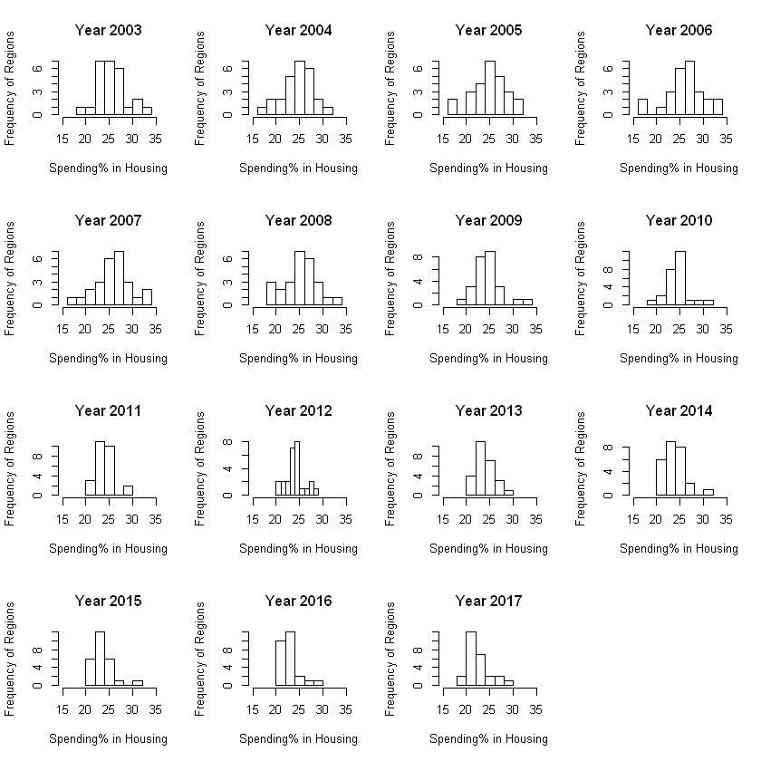

```r
houserent = read.csv("HousingRent.csv")
rownames(houserent) = houserent[1:26,1] #Naming Row Names
houserent = houserent[,-1]              #Dropping first column which was the row names
colnames(houserent) = c(2003:2017)      #Also changed to column names because it showed "X2003", "X2004"...

houserent

par(mfrow=c(4,4))
for (i in 1:length(houserent[1,]))
    hist(houserent[,i],
         main = paste("Year",colnames(houserent)[i]) ,
         xlab = "Spending% in Housing",
         ylab = "Frequency of Regions",
         xlim = c(15,35))
```

In the histograms, it looks like there are not a drastic change over the years except that spending has decreased over the last few years. Maybe, we can see the changes better by plotting regions individually.

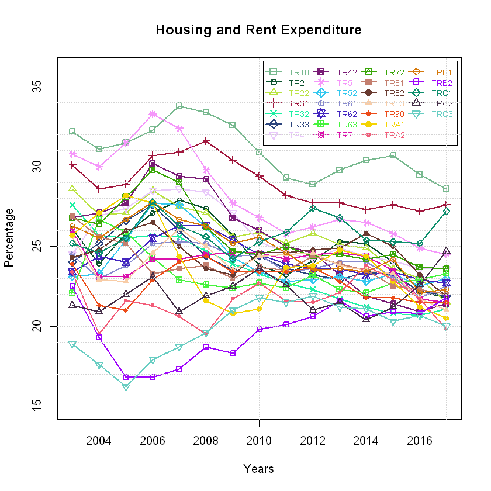

```r
colVector = c("#78b98f", "#0b522e", "#bae342", "#a1173d", "#1cf1a3",
            "#2c457d", "#e9c9fa", "#791c76", "#f597fa", "#35c8ef",
            "#888bce", "#4224bf", "#46f33e", "#db11ac", "#3aa609",
            "#c47f6f", "#693a30", "#f8cca6", "#ec4b18", "#f4d403",
            "#f35c79", "#d6790b", "#9f04fc", "#0e8f6d", "#452e48",
            "#69cec3", "#85cd5d", "#3c0958", "#074a68", "#7ccad5",
            "#b9f78f") # I tried to find 26 distinctive colors.

plot(x = colnames(houserent),
     y = houserent[1,],
     type = "o",
     xlab = "Years", ylab = "Percentage",
     lwd = 2, col = colVector[1], pch=0,
     ylim = c(15, 36))

for(i in 2:26)
    lines(x = colnames(houserent),
          y = houserent[i,],
          col = colVector[i], pch = i-1,
          lwd = 2, type = "o")
title("Housing and Rent Expenditure")
legend("topright", rownames(houserent), cex=0.7, pt.cex=1.2,
       pch=c(0:25),col=colVector, text.col=colVector, lwd=2, ncol= 4, inset = c(0.01, 0.01))

abline(v=(seq(2003,2017,1)), col="lightgray", lty="dotted")
abline(h=(seq(15,35,1)), col="lightgray", lty="dotted")
```

It is possible to say that we can see a slightly decreasing trend in this graph. Conversely, there some regions where the percantages have increased over time. In another aspect, it is clearly seen that the lines get cramped over time, therefore, we can say variation of percantage spending in housing and rent in different regions have become smaller.

Below, we will inspect the data of search results "kiralık ev" and "satılık ev" from Google Trends for Turkey. However, be noted that year 2020 is not finished at the moment, values of 2020 will not be accurate. And Google Trends data start with year 2004, not 2003. Similarly, the expenditure data ends in 2017.

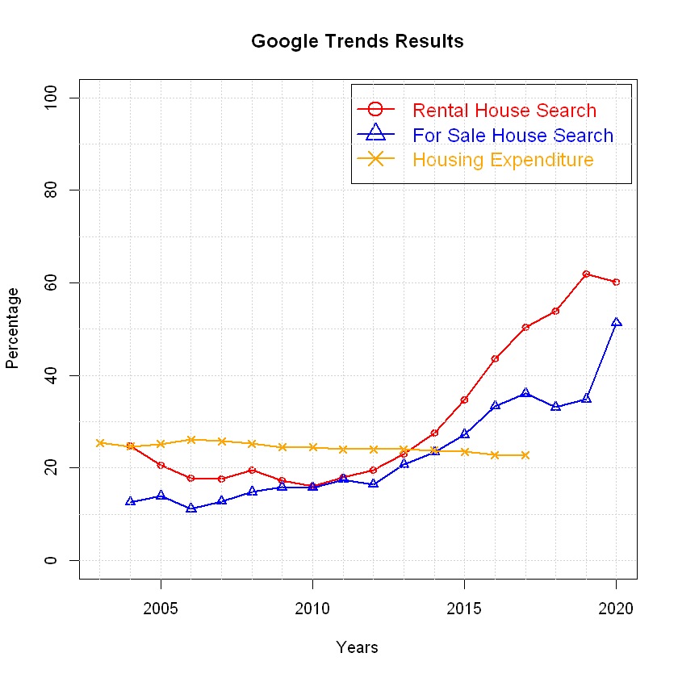

```r
rentalHouse = read.csv("kiralikev.csv")
forsaleHouse = read.csv("satilikev.csv")

# We need to put these monthly data in yearly format

rentalHouseYearly = seq(0,0, length.out = length(rentalHouse[,1])/12 )
forsaleHouseYearly = seq(0,0, length.out = length(forsaleHouse[,1])/12 )

dummyVec = rep(1:ceiling(length(rentalHouse[,1])/12), length.out = length(rentalHouse[,1]), each = 12)

for(i in 1:length(rentalHouse[,2])){
    rentalHouseYearly[dummyVec[i]] = rentalHouseYearly[dummyVec[i]] + rentalHouse[i,2]
    }
rentalHouseYearly = rentalHouseYearly / 12

for(i in 1:length(forsaleHouse[,2])){
    forsaleHouseYearly[dummyVec[i]] = forsaleHouseYearly[dummyVec[i]] + forsaleHouse[i,2]
    }
forsaleHouseYearly = forsaleHouseYearly / 12

# I know that this is not the most conventional method. I need to find a better way to do this.
# But I checked the values and they are correct. This will do for now.

# Let's calculate means of years of housing and renting expeniture percentage.
# Below, I took the arithmetic averages of regions,
# however, it would be more accurate to take population weighted averages.

meansOfHouseRents = seq(0, 0, length.out = length(houserent[1,]))
for(i in 1:length(houserent[1,])){
    meansOfHouseRents[i] = mean(houserent[,i])
    }

# Let's plot

plot(x = c(2004:2020), y = rentalHouseYearly,
     col = "red", lwd = 2, pch = 1, type = "o",
     xlab = "Years", ylab = "Percentage", xlim = c(2003,2020), ylim = c(0,100),
     main = "Google Trends Results")
lines(x = c(2004:2020), y = forsaleHouseYearly,
      col="blue", lwd=2, pch=2, type="o")
lines(x = c(2003:2017), y = meansOfHouseRents,
      col="orange", lwd=2, pch=4, type="o")
legend("topright", c("Rental House Search", "For Sale House Search", "Housing Expenditure"),
       col = c("red", "blue", "orange"), text.col = c("red", "blue", "orange"),
       pch = c(1,2,4), lwd = 2, inset = c(0.01, 0.01), cex = 1.2, pt.cex = 2)

abline(v=(seq(2003,2020,1)), col="lightgray", lty="dotted")
abline(h=(seq(0,100,10)), col="lightgray", lty="dotted")
```

Now, before commenting on the graph, it should be noted that the trend percentages' means and the spending percentages differ in nature. What I mean is that the ways that those two datasets calculated probably doesn't allow them to be compared directly. It is arguable whether they should be plotted on the same graph. I plotted anyway for visual purposes.

Google search results of rental housing and for sale housing show increasing trends, while expenditure percentage of housing and renting are fairly constant over time. My opinion on this subject is that since housing is such a basic need, for its percantage to change drastically over time there has to be a national or global economic boom or crisis. It is not suprising that it is fairly constant. However, increasing trends of search results show us, in my opinion, that the medium of looking for houses to buy or rent has moved to internet over time with the help of widespreading usage of technology and internet. It looks like people started to prefer the internet to search for suitable housing compared to old methods such as touring neighborhoods and calling numbers on the windows or consulting real estate offices.

# Measure 2: Food And Non-Alcholic Beverages

From the same data set, I inspected the percentages of food and non-alcholic beverages of household expenditures.

|  | 2003 | 2004 | 2005 | 2006 | 2007 | 2008 | 2009 | 2010 | 2011 | 2012 | 2013 | 2014 | 2015 | 2016 | 2017 |
| --- | --- | --- | --- | --- | --- | --- | --- | --- | --- | --- | --- | --- | --- | --- | --- |
| TR10 | 20.3 | 20.7 | 20.6 | 19.3 | 18.9 | 17.9 | 17.6 | 16.6 | 16.3 | 16.1 | 15.8 | 15.6 | 15.5 | 15.6 | 15.9 |
| TR21 | 25.4 | 22.3 | 20.6 | 21.0 | 21.6 | 22.9 | 20.8 | 19.9 | 19.4 | 19.5 | 20.3 | 19.7 | 19.5 | 18.3 | 19.3 |
| TR22 | 29.0 | 30.1 | 27.5 | 25.6 | 24.0 | 23.2 | 21.4 | 19.1 | 20.5 | 22.4 | 24.6 | 24.2 | 23.6 | 22.9 | 22.7 |
| TR31 | 21.4 | 19.9 | 21.1 | 21.5 | 22.0 | 20.3 | 20.1 | 18.4 | 17.8 | 17.8 | 18.0 | 18.0 | 17.5 | 18.0 | 18.5 |
| TR32 | 30.0 | 25.6 | 24.0 | 22.7 | 23.5 | 22.6 | 22.3 | 20.0 | 18.9 | 20.3 | 22.1 | 23.3 | 21.8 | 20.8 | 20.9 |
| TR33 | 32.2 | 26.1 | 25.6 | 26.2 | 26.8 | 25.6 | 24.3 | 22.7 | 21.9 | 22.1 | 20.9 | 21.5 | 21.0 | 22.0 | 22.1 |
| TR41 | 25.7 | 23.1 | 22.6 | 21.9 | 21.6 | 20.5 | 20.1 | 19.1 | 18.9 | 18.1 | 18.2 | 18.0 | 18.8 | 18.3 | 19.1 |
| TR42 | 26.9 | 23.5 | 24.2 | 22.4 | 23.0 | 22.3 | 21.7 | 20.8 | 19.6 | 19.4 | 18.9 | 18.5 | 18.8 | 18.7 | 19.9 |
| TR51 | 21.1 | 21.0 | 20.3 | 19.9 | 19.5 | 19.0 | 18.4 | 17.6 | 17.3 | 16.5 | 16.9 | 16.7 | 17.3 | 17.8 | 18.3 |
| TR52 | 29.4 | 25.5 | 25.0 | 22.4 | 23.0 | 22.4 | 22.1 | 21.3 | 20.9 | 20.1 | 19.8 | 20.4 | 20.8 | 21.1 | 21.5 |
| TR61 | 25.6 | 23.4 | 23.3 | 22.2 | 22.1 | 22.6 | 23.1 | 21.2 | 19.5 | 18.2 | 17.5 | 18.0 | 18.7 | 19.6 | 19.7 |
| TR62 | 30.1 | 27.8 | 26.9 | 24.9 | 24.4 | 23.8 | 22.6 | 21.0 | 19.5 | 19.4 | 20.3 | 20.7 | 21.4 | 21.4 | 21.7 |
| TR63 | 32.7 | 29.8 | 28.3 | 27.4 | 28.3 | 27.7 | 26.3 | 25.2 | 24.3 | 24.2 | 22.7 | 22.2 | 22.6 | 23.4 | 25.2 |
| TR71 | 31.2 | 31.5 | 31.6 | 29.0 | 27.2 | 26.2 | 27.5 | 24.5 | 24.5 | 23.0 | 25.6 | 24.2 | 25.3 | 25.4 | 26.7 |
| TR72 | 34.7 | 30.9 | 27.7 | 26.3 | 25.4 | 25.5 | 23.7 | 22.9 | 22.8 | 22.0 | 22.6 | 22.8 | 22.6 | 22.8 | 22.8 |
| TR81 | 33.9 | 29.0 | 28.4 | 27.7 | 27.0 | 25.8 | 24.7 | 23.7 | 22.8 | 21.8 | 21.3 | 21.1 | 19.9 | 20.2 | 20.7 |
| TR82 | 33.8 | 27.0 | 26.1 | 27.4 | 28.0 | 28.1 | 27.7 | 25.9 | 24.8 | 24.4 | 24.6 | 22.4 | 20.9 | 21.0 | 24.3 |
| TR83 | 34.2 | 31.5 | 29.1 | 28.8 | 26.9 | 26.9 | 26.2 | 25.7 | 25.2 | 26.1 | 25.6 | 27.2 | 26.4 | 26.1 | 26.3 |
| TR90 | 31.0 | 29.0 | 27.8 | 26.1 | 26.8 | 26.8 | 26.8 | 25.1 | 24.6 | 24.2 | 22.4 | 21.8 | 22.0 | 22.5 | 24.2 |
| TRA1 | 33.4 | 28.5 | 26.3 | 26.2 | 24.8 | 26.4 | 26.6 | 25.6 | 23.8 | 22.8 | 22.9 | 23.1 | 22.3 | 23.4 | 23.6 |
| TRA2 | 39.6 | 39.3 | 35.7 | 33.9 | 35.4 | 35.7 | 32.9 | 30.6 | 29.7 | 27.8 | 28.4 | 28.5 | 29.3 | 27.5 | 25.4 |
| TRB1 | 29.8 | 30.5 | 29.0 | 25.9 | 24.1 | 22.9 | 21.8 | 21.6 | 22.4 | 22.6 | 22.1 | 21.8 | 23.3 | 22.9 | 24.7 |
| TRB2 | 41.7 | 38.1 | 35.5 | 33.6 | 30.6 | 31.6 | 29.1 | 28.5 | 28.3 | 28.7 | 29.9 | 31.1 | 32.6 | 33.2 | 34.4 |
| TRC1 | 33.7 | 33.3 | 32.9 | 32.7 | 28.2 | 26.2 | 24.5 | 24.8 | 24.3 | 23.7 | 24.0 | 25.5 | 24.2 | 24.2 | 23.6 |
| TRC2 | 41.0 | 41.4 | 41.4 | 39.1 | 35.6 | 30.9 | 29.3 | 28.3 | 28.3 | 27.0 | 27.6 | 28.8 | 27.4 | 28.4 | 28.4 |
| TRC3 | 47.6 | 49.3 | 48.1 | 43.4 | 39.0 | 36.3 | 33.6 | 30.2 | 29.8 | 28.5 | 30.9 | 30.8 | 30.5 | 29.3 | 29.2 |

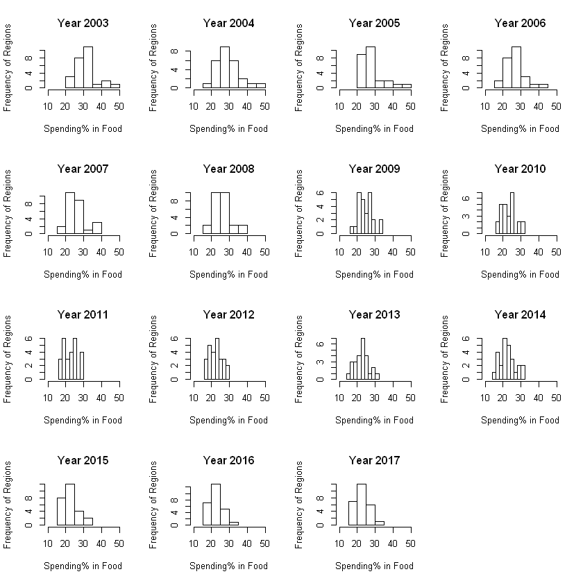

```r
food = read.csv("FoodNonalcholic.csv")
rownames(food) = food[1:26,1]
food = food[,-1]
colnames(food) = c(2003:2017)

food

par(mfrow=c(4,4))
for (i in 1:length(food[1,]))
    hist(food[,i],
         main = paste("Year",colnames(food)[i]) ,
         xlab = "Spending% in Food",
         ylab = "Frequency of Regions",
         xlim = c(10,50))
```

It looks like there has been some outlier regions in the past which had greater percentage. However, in time they disappeared and the values gathered around about 20-25. It is possible to say shapes of the histograms resemble the normal distribution. Let's see the line plot.

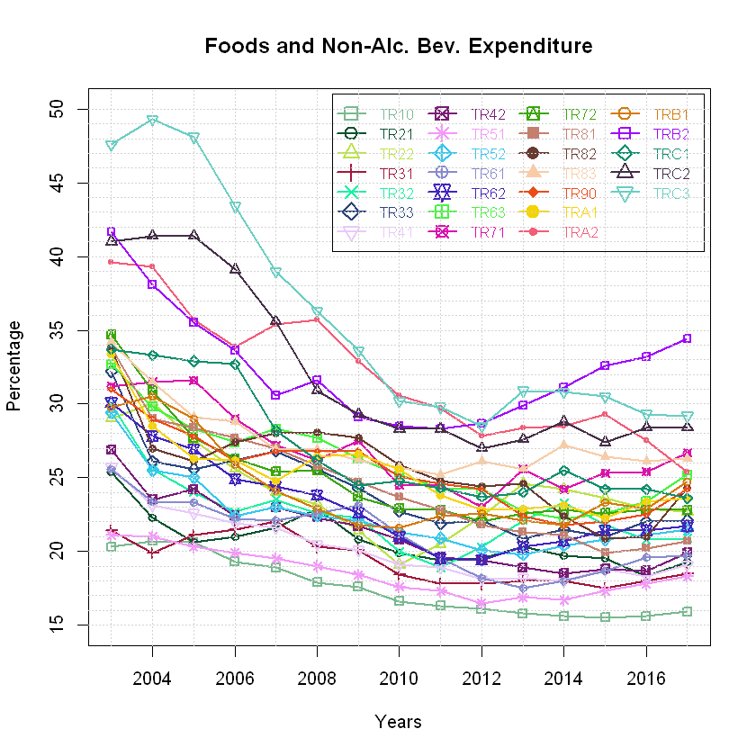

```r
colVector = c("#78b98f", "#0b522e", "#bae342", "#a1173d", "#1cf1a3",
            "#2c457d", "#e9c9fa", "#791c76", "#f597fa", "#35c8ef",
            "#888bce", "#4224bf", "#46f33e", "#db11ac", "#3aa609",
            "#c47f6f", "#693a30", "#f8cca6", "#ec4b18", "#f4d403",
            "#f35c79", "#d6790b", "#9f04fc", "#0e8f6d", "#452e48",
            "#69cec3", "#85cd5d", "#3c0958", "#074a68", "#7ccad5",
            "#b9f78f")

plot(x = colnames(food),
     y = food[1,],
     type = "o",
     xlab = "Years", ylab = "Percentage",
     lwd = 2, col = colVector[1], pch=0,
     ylim = c(15, 50))

for(i in 2:26)
    lines(x = colnames(food),
          y = food[i,],
          col = colVector[i], pch = i-1,
          lwd = 2, type = "o")
title("Foods and Non-Alc. Bev. Expenditure")
legend("topright", rownames(food), cex=0.85, pt.cex=1.5,
       pch=c(0:25),col=colVector, text.col=colVector, lwd=2, ncol= 4, inset = c(0.01, 0.01))

abline(v=(seq(2003,2017,1)), col="lightgray", lty="dotted")
abline(h=(seq(15,50,1)), col="lightgray", lty="dotted")
```

Here, it is easier to see the downfall at the beginning. From 2010, lines progressed rather constant, but it looks like slight increases began in the last 3,4 years.

Below, I graphed the search term popularity results of "yiyecek" and "gıda" in Turkey. Data is from Google Trends. I also calculated the average percentage of food expenditure.

[figure not shown]

```r
gidaSearch = read.csv("gida.csv")
yiyecekSearch = read.csv("yiyecek.csv")

# Again, we need to put these monthly data in yearly format

gidaSearchYearly = seq(0,0, length.out = length(gidaSearch[,1])/12 )
yiyecekSearchYearly = seq(0,0, length.out = length(yiyecekSearch[,1])/12 )

dummyVec = rep(1:ceiling(length(gidaSearch[,1])/12), length.out = length(gidaSearch[,1]), each = 12)

for(i in 1:length(gidaSearch[,2])){
    gidaSearchYearly[dummyVec[i]] = gidaSearchYearly[dummyVec[i]] + gidaSearch[i,2]
    }
gidaSearchYearly = gidaSearchYearly / 12

for(i in 1:length(yiyecekSearch[,2])){
    yiyecekSearchYearly[dummyVec[i]] = yiyecekSearchYearly[dummyVec[i]] + yiyecekSearch[i,2]
    }
yiyecekSearchYearly = yiyecekSearchYearly / 12

meansOfFoodExp = seq(0, 0, length.out = length(food[1,]))
for(i in 1:length(food[1,])){
    meansOfFoodExp[i] = mean(food[,i])
    }

# Let's plot

plot(x = c(2004:2020), y = gidaSearchYearly,
     col = "red", lwd = 2, pch = 1, type = "o",
     xlab = "Years", ylab = "Percentage", xlim = c(2003,2020), ylim = c(0,100),
     main = "Google Trends Results")
lines(x = c(2004:2020), y = yiyecekSearchYearly,
      col="blue", lwd=2, pch=2, type="o")
lines(x = c(2003:2017), y = meansOfFoodExp,
      col="orange", lwd=2, pch=4, type="o")
legend("topright", c("'Gida' Search", "'Yiyecek' Search", "Food Expenditure"),
       col = c("red", "blue", "orange"), text.col = c("red", "blue", "orange"),
       pch = c(1,2,4), lwd = 2, inset = c(0.01, 0.01), cex = 1.2, pt.cex = 2)

abline(v=(seq(2003,2020,1)), col="lightgray", lty="dotted")
abline(h=(seq(0,100,10)), col="lightgray", lty="dotted")
```

Like the expenditure, search terms also had high values and a downfall at the beginning. Afterwards, search term 'Gida' progressed rather constantly. With year 2011, the search term 'Yiyecek' had a notable positive trend. The reason for that could be people searching for restaurants or similars on the internet. Also, in the year 2020, we can easily see the unpopularity of 'Yiyecek' which is most probably an effect of the Covid-19 period.

# Measure 3: Restaurant and Hotels

Percentage expenditure on restaurants and hotels are inspected. Measure is from the same dataset. However, this measure differs from the other two in the fact that this one is not a basic/primal need but rather is an optional, secondary or even luxurious need. Processes below are similar to the other two.

|  | 2003 | 2004 | 2005 | 2006 | 2007 | 2008 | 2009 | 2010 | 2011 | 2012 | 2013 | 2014 | 2015 | 2016 | 2017 |
| --- | --- | --- | --- | --- | --- | --- | --- | --- | --- | --- | --- | --- | --- | --- | --- |
| TR10 | 5.9 | 6.1 | 6.2 | 6.2 | 6.2 | 6.4 | 6.7 | 6.9 | 7.1 | 7.2 | 7.4 | 7.3 | 7.4 | 7.4 | 7.6 |
| TR21 | 6.0 | 6.2 | 5.8 | 5.9 | 6.4 | 6.5 | 6.5 | 6.6 | 6.6 | 6.6 | 6.6 | 7.0 | 7.1 | 7.1 | 6.8 |
| TR22 | 3.4 | 3.5 | 3.5 | 3.7 | 4.8 | 4.9 | 5.8 | 5.6 | 6.5 | 5.9 | 6.1 | 6.6 | 7.2 | 7.1 | 6.9 |
| TR31 | 5.2 | 5.1 | 4.9 | 4.9 | 5.1 | 5.0 | 5.5 | 5.9 | 6.2 | 6.4 | 6.9 | 7.1 | 7.2 | 7.1 | 7.1 |
| TR32 | 3.0 | 3.7 | 4.0 | 4.1 | 4.6 | 5.0 | 5.7 | 6.1 | 6.3 | 5.9 | 5.9 | 6.0 | 6.4 | 6.7 | 6.8 |
| TR33 | 3.8 | 3.5 | 3.0 | 3.4 | 4.3 | 5.0 | 5.1 | 4.7 | 4.7 | 4.7 | 5.0 | 5.0 | 5.6 | 5.7 | 6.2 |
| TR41 | 5.6 | 5.3 | 5.1 | 5.3 | 5.6 | 6.0 | 6.4 | 6.7 | 6.7 | 7.2 | 7.1 | 7.6 | 7.5 | 7.8 | 7.8 |
| TR42 | 4.7 | 4.4 | 4.2 | 4.4 | 4.2 | 4.2 | 4.6 | 4.8 | 5.0 | 5.1 | 5.2 | 5.6 | 5.8 | 6.0 | 5.9 |
| TR51 | 4.8 | 4.3 | 4.0 | 4.2 | 4.9 | 5.7 | 6.1 | 6.3 | 6.4 | 6.5 | 6.6 | 6.8 | 6.6 | 6.4 | 6.5 |
| TR52 | 3.3 | 3.5 | 3.9 | 3.7 | 3.9 | 4.3 | 5.4 | 5.9 | 6.0 | 6.1 | 5.8 | 5.8 | 6.1 | 6.7 | 6.7 |
| TR61 | 3.1 | 3.5 | 4.0 | 4.7 | 4.9 | 4.9 | 5.6 | 5.9 | 6.2 | 6.5 | 7.2 | 7.6 | 7.3 | 7.2 | 7.1 |
| TR62 | 4.0 | 3.9 | 3.7 | 3.5 | 3.6 | 4.1 | 4.6 | 5.1 | 5.3 | 5.8 | 5.6 | 5.6 | 5.4 | 5.8 | 6.1 |
| TR63 | 3.5 | 2.8 | 2.6 | 2.8 | 4.4 | 4.7 | 5.1 | 4.8 | 4.6 | 4.5 | 4.6 | 4.5 | 4.4 | 4.5 | 4.5 |
| TR71 | 2.2 | 2.7 | 2.6 | 2.9 | 3.0 | 3.4 | 3.9 | 4.3 | 4.5 | 4.3 | 4.3 | 4.4 | 4.5 | 4.6 | 4.5 |
| TR72 | 2.2 | 2.4 | 2.7 | 2.9 | 3.2 | 3.3 | 3.7 | 4.0 | 4.1 | 4.5 | 4.5 | 4.8 | 4.5 | 4.5 | 4.6 |
| TR81 | 2.4 | 2.8 | 3.2 | 4.2 | 4.9 | 5.1 | 4.9 | 4.8 | 5.3 | 6.5 | 6.2 | 6.4 | 6.3 | 6.9 | 6.7 |
| TR82 | 2.7 | 2.4 | 2.1 | 2.3 | 3.0 | 3.4 | 3.6 | 3.0 | 2.6 | 2.7 | 2.9 | 3.5 | 3.8 | 4.0 | 4.3 |
| TR83 | 3.1 | 3.4 | 3.2 | 3.0 | 3.5 | 3.6 | 4.1 | 3.7 | 3.8 | 3.7 | 4.2 | 4.0 | 3.9 | 4.2 | 4.2 |
| TR90 | 3.1 | 3.8 | 3.9 | 3.2 | 3.0 | 3.0 | 3.5 | 4.0 | 4.6 | 5.3 | 5.6 | 5.9 | 5.8 | 5.9 | 5.7 |
| TRA1 | 2.7 | 4.4 | 4.1 | 2.3 | 2.5 | 2.9 | 3.8 | 4.0 | 4.2 | 3.8 | 3.4 | 3.2 | 3.6 | 4.3 | 5.0 |
| TRA2 | 0.7 | 1.1 | 1.7 | 2.4 | 2.6 | 2.9 | 2.9 | 2.6 | 2.6 | 3.1 | 3.1 | 3.4 | 3.7 | 4.7 | 5.3 |
| TRB1 | 3.0 | 3.5 | 3.5 | 4.0 | 4.4 | 5.4 | 6.0 | 5.9 | 5.5 | 5.0 | 5.7 | 5.7 | 5.9 | 5.5 | 5.3 |
| TRB2 | 2.6 | 2.7 | 3.0 | 3.2 | 3.7 | 3.7 | 5.0 | 5.4 | 5.4 | 5.3 | 5.7 | 5.3 | 4.4 | 3.6 | 2.7 |
| TRC1 | 4.2 | 2.9 | 2.5 | 2.3 | 2.7 | 3.5 | 4.5 | 5.0 | 4.9 | 4.3 | 4.4 | 3.8 | 3.6 | 3.8 | 4.2 |
| TRC2 | 1.9 | 1.2 | 1.4 | 1.8 | 2.2 | 3.1 | 3.0 | 2.8 | 2.5 | 3.7 | 4.5 | 5.0 | 4.2 | 3.9 | 3.2 |
| TRC3 | 1.2 | 1.2 | 0.7 | 0.9 | 1.2 | 1.4 | 1.8 | 2.4 | 3.0 | 3.2 | 3.6 | 4.0 | 5.1 | 5.8 | 6.1 |

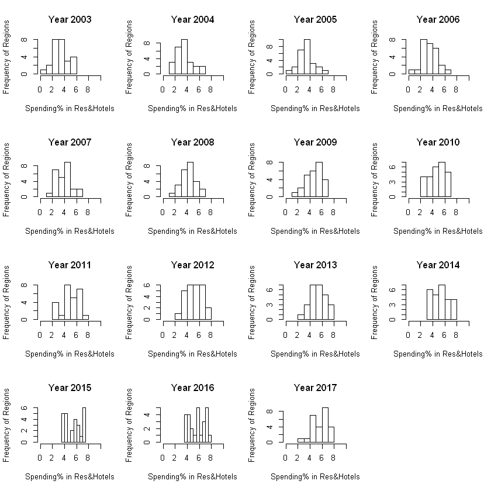

```r
restaurantsHotels = read.csv("RestaurantsHotels.csv")
rownames(restaurantsHotels) = restaurantsHotels[1:26,1]
restaurantsHotels = restaurantsHotels[,-1]
colnames(restaurantsHotels) = c(2003:2017)

restaurantsHotels

par(mfrow=c(4,4))
for (i in 1:length(restaurantsHotels[1,]))
    hist(restaurantsHotels[,i],
         main = paste("Year",colnames(restaurantsHotels)[i]) ,
         xlab = "Spending% in Res&Hotels",
         ylab = "Frequency of Regions",
         xlim = c(0,10)) #Decided on these values using min(),max()
```

Inspecting the histograms visually, we can come up with the idea that the expenditure has increased over time. It looks like the shape was like the normal distribution at first years and took the shape of uniform distribution over year, but that's an ambitious comment made considering it is only from visual evidence. Let's see the plot.

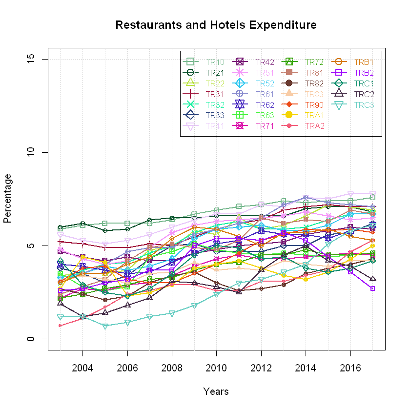

```r
colVector = c("#78b98f", "#0b522e", "#bae342", "#a1173d", "#1cf1a3",
            "#2c457d", "#e9c9fa", "#791c76", "#f597fa", "#35c8ef",
            "#888bce", "#4224bf", "#46f33e", "#db11ac", "#3aa609",
            "#c47f6f", "#693a30", "#f8cca6", "#ec4b18", "#f4d403",
            "#f35c79", "#d6790b", "#9f04fc", "#0e8f6d", "#452e48",
            "#69cec3", "#85cd5d", "#3c0958", "#074a68", "#7ccad5",
            "#b9f78f")

plot(x = colnames(restaurantsHotels),
     y = restaurantsHotels[1,],
     type = "o",
     xlab = "Years", ylab = "Percentage",
     lwd = 2, col = colVector[1], pch=0,
     ylim = c(0, 15))

for(i in 2:26)
    lines(x = colnames(restaurantsHotels),
          y = restaurantsHotels[i,],
          col = colVector[i], pch = i-1,
          lwd = 2, type = "o")
title("Restaurants and Hotels Expenditure")
legend("topright", rownames(restaurantsHotels), cex=0.85, pt.cex=1.5,
       pch=c(0:25),col=colVector, text.col=colVector, lwd=2, ncol= 4, inset = c(0.01, 0.01))

abline(v=(seq(2003,2017,1)), col="lightgray", lty="dotted")
abline(h=(seq(15,50,1)), col="lightgray", lty="dotted")
```

It looks like the cluster of lines have a slight positive trend. Yet, few lines had a notable negative trend in the last years. Could the overall positive trend mean an improvement on the life of people/households in Turkey? That is probably a topic that requires extensive research.

Below is the popularity of the search results of "restoran" and "otel". The data is from Google Trends.

[figure not shown]

```r
restoranSearch = read.csv("restoranSearch.csv")
otelSearch = read.csv("otelSearch.csv")

# Again, we need to put these monthly data in yearly format

restoranSearchYearly = seq(0,0, length.out = length(restoranSearch[,1])/12 )
otelSearchYearly = seq(0,0, length.out = length(otelSearch[,1])/12 )

dummyVec = rep(1:ceiling(length(restoranSearch[,1])/12), length.out = length(restoranSearch[,1]), each = 12)

for(i in 1:length(restoranSearch[,2])){
    restoranSearchYearly[dummyVec[i]] = restoranSearchYearly[dummyVec[i]] + restoranSearch[i,2]
    }
restoranSearchYearly = restoranSearchYearly / 12

for(i in 1:length(otelSearch[,2])){
    otelSearchYearly[dummyVec[i]] = otelSearchYearly[dummyVec[i]] + otelSearch[i,2]
    }
otelSearchYearly = otelSearchYearly / 12

meansOfResHotelExp = seq(0, 0, length.out = length(restaurantsHotels[1,]))
for(i in 1:length(restaurantsHotels[1,])){
    meansOfResHotelExp[i] = mean(restaurantsHotels[,i])
    }

# Let's plot

plot(x = c(2004:2020), y = restoranSearchYearly,
     col = "red", lwd = 2, pch = 1, type = "o",
     xlab = "Years", ylab = "Percentage", xlim = c(2003,2020), ylim = c(0,100),
     main = "Google Trends Results")
lines(x = c(2004:2020), y = otelSearchYearly,
      col="blue", lwd=2, pch=2, type="o")
lines(x = c(2003:2017), y = meansOfResHotelExp,
      col="orange", lwd=2, pch=4, type="o")
legend("topright", c("'Restoran' Search", "'Otel' Search", "Res. & Hotels Expenditure"),
       col = c("red", "blue", "orange"), text.col = c("red", "blue", "orange"),
       pch = c(1,2,4), lwd = 2, inset = c(0.01, 0.01), cex = 1.2, pt.cex = 2)

abline(v=(seq(2003,2020,1)), col="lightgray", lty="dotted")
abline(h=(seq(0,100,10)), col="lightgray", lty="dotted")
```

The results are quite unexpected. Search terms have negative trend, unlike the expenditure percantage. Near year 2013, search terms' popularity start to increase again. I don't have a reasonable explanation for the strange movement of the search terms. One thing that is noticable is the drop of the popularity of search terms in year 2020, again presumably caused by the Covid-19 Epidemic.

# Conclusion

In this homework I inspected three different measures from the dataset of yearly expenditure percantage of households in Turkey. While brushing up on skills of data management, coding and plotting in R, I also discussed the movement of the values in the data and its similarity to relavent search terms' popularities. I hope that I filled the expectations of the homework.